# “And it came to pass…”

- Show All Code
- Hide All Code
- View Source

Author

Austin Mangelson

Mark Twain, the celebrated American writer most famous for *The Adventures of Tom Sawyer* and *The Adventures of Huckleberry Finn*, got his hands on a copy of the Book of Mormon while on a trip to Salt Lake City in 1861. To put it mildly, he wasn’t a big fan.

“*It is chloroform in print,*” Twain wrote. “*If Joseph Smith composed this book, the act was a miracle - keeping awake while he did it was, at any rate.*”

But one thing Mark Twain mentioned in his review of the Book of Mormon will resonate with just about any reader. “*‘And it came to pass’ was his pet. If he had left that out, his Bible would have been only a pamphlet.*”

Any reader of the Book of Mormon will quickly realize just how many times the phrase ‘*and it came to pass*’ appears. But just how many times, exactly? Although meant sarcastically, just how true is the claim that the Book of Mormon would be significantly shorter without the phrase ‘*and it came to pass*’?

## Number of Appearances

Overall, the phrase ‘*and it came to pass*’ appears in the Book of Mormon 1,127 times.

[output not shown]

That seems like a lot! But is it really? How does removing this phrase change the length of the book?

## Without the phrase “*and it came to pass*”

There are a total of 1,406,719 words in the Book of Mormon. That puts our 1,127 from the “and it came to pass”-o-meter into a bit of perspective.

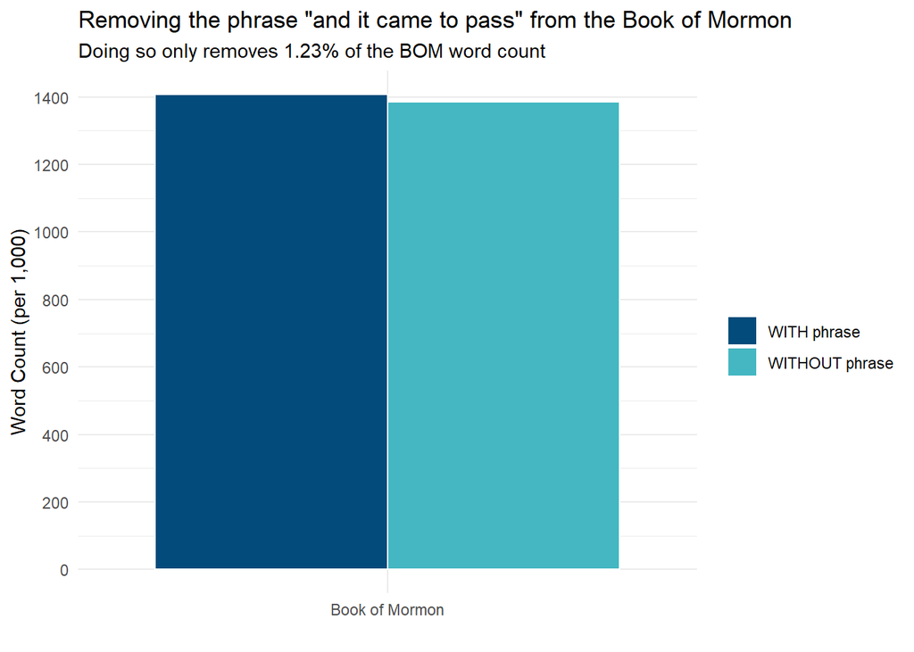

```r
book_of_mormon <- scriptures |>
  filter(volume_title == "Book of Mormon")

book_of_mormon_3 <-  book_of_mormon |>
  mutate(text_without_came_to_pass = str_replace_all(scripture_text, 'for it came to pass|and it came to pass', "")) |>
  mutate(new_word_count = str_count(text_without_came_to_pass)) |>
  select(-volume_id, -book_id, -chapter_id, -verse_id, -volume_long_title, -book_long_title, -book_subtitle, -volume_short_title, -volume_lds_url, -book_lds_url)


book_of_mormon_word_count_3 <-
  book_of_mormon_3 |>
  group_by(volume_title) |>
  summarise(word_count = sum(word_count),
            Count_without_came_to_pass = sum(new_word_count)
  ) |>
  pivot_longer(cols = c("word_count", "Count_without_came_to_pass"),
               names_to = "count_type",
               values_to = "word_count") |>
  mutate(count_type = fct_recode(count_type,
                                 "WITHOUT phrase" = "Count_without_came_to_pass",
                                 "WITH phrase" = "word_count")) |>
  mutate(word_count_per_1000 = word_count / 1000)

book_of_mormon_word_count_3$count_type <- factor(book_of_mormon_word_count_3$count_type, levels = c("WITH phrase", "WITHOUT phrase"))


ggplot(book_of_mormon_word_count_3, aes(x = volume_title, y = word_count_per_1000, fill = count_type)) +
  geom_bar(stat = "identity", position = "dodge", color = "white") +
  theme_minimal() +
  scale_fill_manual(values = c("#024B7A", "#44B7C2")) +
  labs(
    title = "Removing the phrase \"and it came to pass\" from the Book of Mormon",
    subtitle = "Doing so only removes 1.23% of the BOM word count",
    x = "",
    y = "Word Count (per 1,000)",
    fill = ""
  ) +
  scale_y_continuous(n.breaks = 8)
```

Let’s break that down by each book in the Book of Mormon.

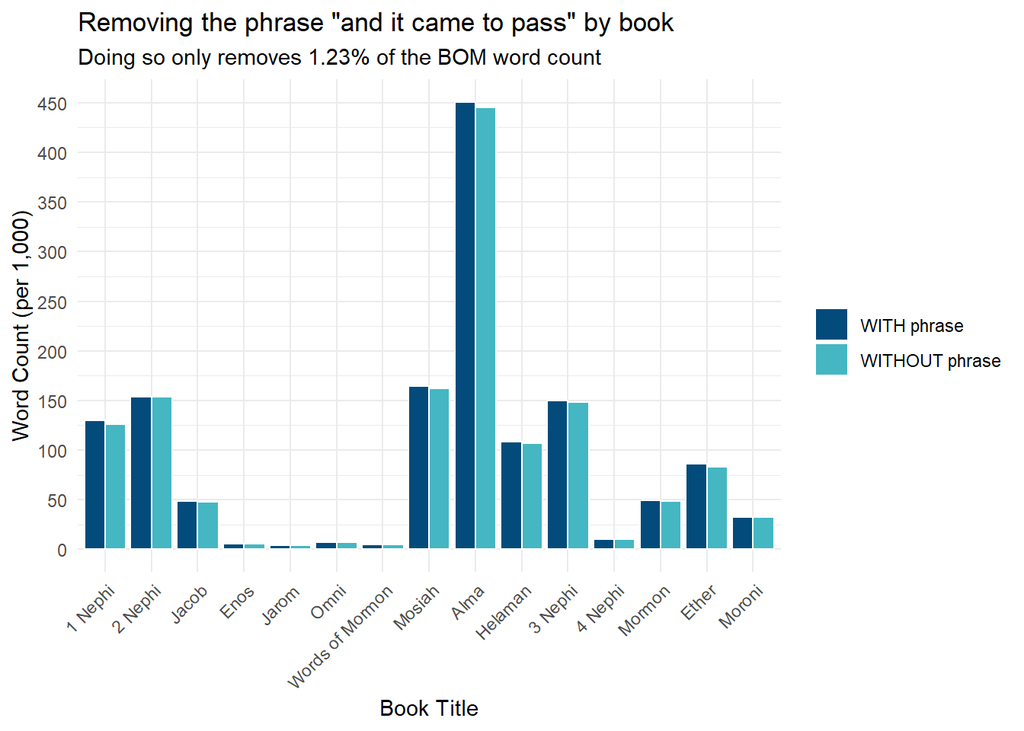

```r
book_of_mormon_word_count_2$count_type <- factor(book_of_mormon_word_count_2$count_type, levels = c("WITH phrase", "WITHOUT phrase"))


ggplot(book_of_mormon_word_count_2, aes(x = book_title, y = word_count_per_1000, fill = count_type)) +
  geom_bar(stat = "identity", position = "dodge", color = "white") +
  theme_minimal() +
  scale_fill_manual(values = c("#024B7A", "#44B7C2")) +
  labs(
    title = "Removing the phrase \"and it came to pass\" by book",
    subtitle = "Doing so only removes 1.23% of the BOM word count",
    x = "Book Title",
    y = "Word Count (per 1,000)",
    fill = ""
  ) +
  scale_y_continuous(n.breaks = 10) +
  theme(axis.text.x = element_text(angle = 45, vjust = 1, hjust=1))
```